# Campaign Finance Networks in the US, Part I

By Mark Hand

25 October, 2017

## Getting started

This script generates a the dataframes necessary to map of donations to candidates for US federal office in 2017-2018, according to the US government’s Federal Election Commission (FEC).

### Background

Federal law requires that campaigns report any donation over $200. Some notes of caution to the reader: This does not include donations to or expenditures from Super PACs, which have to report political donations but (I think) not non-campaign expenditures , or to 5014c4 organiations, which do not have to (publicly) political donations. It also doesn’t include money spent on “issue ads,” which don’t (legally) qualify as political speech.

### Data Stuff

Anywho, you can get all this data directly from the [FEC website](http://classic.fec.gov/finance/disclosure/ftpdet.shtml#a2017_2018) or [Mark’s Dropbox](https://www.dropbox.com/sh/dtvzgyp4blf3mb3/AAC8OJNTjH3xisLro3sMRHDya?dl=0). I converted each of these .txt files to .csv using Text to Column in Excel. **Be careful here**, as there seem to be more observations in those files than in the direct .txt files I am trying to learn how to read in. This is (almost all) done in [RStudio](https://www.rstudio.com/) using [RMarkdown](http://rmarkdown.rstudio.com/).

### Getting ready

If you want to replicate this, you’ll need to install R and RStudio, then open [this](https://www.dropbox.com/s/sa5a5vvs76zg6ko/Exercise_5_FEC.Rmd?dl=0) file. Then run the following, replacing `setwd("~/Dropbox/PhD_data/FEC")` with `setwd("Wherever you downloaded that file")`.

```r
setwd("~/Dropbox/PhD_data/FEC")
library(data.table)
library(tidyverse)
library(WriteXLS)
library(readxl)
library(readr)
library(stringr)
library(igraph)
library(knitr)
library(grid)
library(gridExtra)
```

If you’re new to RStudio, then you will probably get a bunch of error messages here. If that’s the case, you’ll need to install each of the packages listed above with commands like `install.packages("tidyverse")`.

## Importing data

If you downloaded the Dropbox folder, you should see some .csv files that I created from the .txt files that I downloaded from the FEC website. Start importing and cleaning that data.

### Donations (links)

This file will become the `links` in our network; it has all the donations in the 2017-2018 cycle, whether that be from an individual donor or another political committee. It includes both Republicans and Democrats. **Careful** with the file addresses here; they’ll need to be edited to wherever you downloaded the Dropbox folder.

```r
US1 <- read_csv("~/Dropbox/PhD_data/FEC/itcont_2018_20170531_20171103.csv", col_names=F)
ind_names <- c("CMTE_ID","AMNDT_IND","RPT_TP","TRANSACTION_PGI","IMAGE_NUM","TRANSACTION_TP","ENTITY_TP","NAME","CITY","STATE","ZIP_CODE","EMPLOYER","OCCUPATION","TRANSACTION_DT","TRANSACTION_AMT","OTHER_ID","TRAN_ID","FILE_NUM","MEMO_CD","MEMO_TEXT","SUB_ID")
colnames(US1) = ind_names
US2 <- read_csv("~/Dropbox/PhD_data/FEC/itcont_2018_20120521_20170530.csv", col_names=F)
colnames(US2) = ind_names
US3 <- read_csv("~/Dropbox/PhD_data/FEC/itcont_2018_invalid_dates.csv", col_names=F)
colnames(US3) = ind_names
donations <- rbind(US1, US2, US3)
donations$IMAGE_NUM <- as.numeric(donations$IMAGE_NUM)
donations$ZIP_CODE <- as.numeric(donations$ZIP_CODE)
donations$TRANSACTION_DT <- as.numeric(donations$TRANSACTION_DT)
donations$TRANSACTION_AMT <- as.numeric(donations$TRANSACTION_AMT)
donations$FILE_NUM <- as.numeric(donations$FILE_NUM)
donations$SUB_ID <- as.numeric(donations$SUB_ID)
donations %>%
  rename("from" = "NAME") -> donations

comtocom <- read_csv("~/Dropbox/PhD_data/FEC/itoth.csv", col_names=F)
itothnames <- c("CMTE_ID","AMNDT_IND","RPT_TP","TRANSACTION_PGI","IMAGE_NUM","TRANSACTION_TP","ENTITY_TP","NAME","CITY","STATE","ZIP_CODE","EMPLOYER","OCCUPATION","TRANSACTION_DT","TRANSACTION_AMT","OTHER_ID","TRAN_ID","FILE_NUM","MEMO_CD","MEMO_TEXT","SUB_ID")
colnames(comtocom) = itothnames
comtocom %>%
  rename("from" = "OTHER_ID") -> comtocom

comtocan <- read_csv("~/Dropbox/PhD_data/FEC/itpas2.csv", col_names=F)
itpas2names <- c("CMTE_ID","AMNDT_IND","RPT_TP","TRANSACTION_PGI","IMAGE_NUM","TRANSACTION_TP","ENTITY_TP","NAME","CITY","STATE","ZIP_CODE","EMPLOYER","OCCUPATION","TRANSACTION_DT","TRANSACTION_AMT","OTHER_ID","CAND_ID","TRAN_ID","FILE_NUM","MEMO_CD","MEMO_TEXT","SUB_ID")
colnames(comtocan) = itpas2names
comtocan %>%
  rename("from" = "OTHER_ID") -> comtocan

links <- bind_rows(donations, comtocom, comtocan)
links %>% rename("to" = "CMTE_ID") -> links
links <- links %>% select(from, to, everything())
```

### Campaigns, candidates and donors (nodes)

These data will become the `nodes` in our network map.

```r
candidates <- read_csv("~/Dropbox/PhD_data/FEC/cn.csv", col_names=F)
can_col_names <- c("CAND_ID","CAND_NAME","CAND_PTY_AFFILIATION","CAND_ELECTION_YR","CAND_OFFICE_ST","CAND_OFFICE","CAND_OFFICE_DISTRICT","CAND_ICI","CAND_STATUS","CAND_PCC","CAND_ST1","CAND_ST2","CAND_CITY","CAND_ST","CAND_ZIP")
colnames(candidates) = can_col_names

committees <- read_csv("~/Dropbox/PhD_data/FEC/cm.csv", col_names=F)
com_col_names <- c("CMTE_ID","CMTE_NM","TRES_NM","CMTE_ST1","CMTE_ST2","CMTE_CITY","CMTE_ST","CMTE_ZIP","CMTE_DSGN","CMTE_TP","CMTE_PTY_AFFILIATION","CMTE_FILING_FREQ","ORG_TP","CONNECTED_ORG_NM","CAND_ID")
colnames(committees) = com_col_names

recipients <- full_join(candidates, committees)

donors <- donations %>%
  select("from","CITY","STATE","ZIP_CODE","EMPLOYER","OCCUPATION") %>%
  distinct()

nodes <- bind_rows(recipients, donors)
nodes <- mutate(nodes, id = rownames(nodes))
nodes <- nodes %>% select(id, everything())
```

# Tables and Charts

Before we build a graph of that data, let’s take a look at where the money is flowing.

```r
kitchensink <- left_join(links, recipients, by = c("to" = "CMTE_ID"))
```

## Two Charts

Let’s get rid of Chet Edwards and other non-2018 races and create a new dataframe to play with.

```r
kitchensink %>%
  filter(CAND_OFFICE_ST=="TX" & CAND_OFFICE=="H" & CAND_ELECTION_YR=="2018") %>%
  group_by(CAND_NAME) %>%
  mutate(TOTAL = sum(TRANSACTION_AMT)) %>%
  select(CAND_NAME, CAND_OFFICE_DISTRICT, CAND_PTY_AFFILIATION, TOTAL) %>%
  distinct() %>%
  arrange(desc(TOTAL)) -> TX_House
```

### Chart I

Which house races are the most expensive so far?

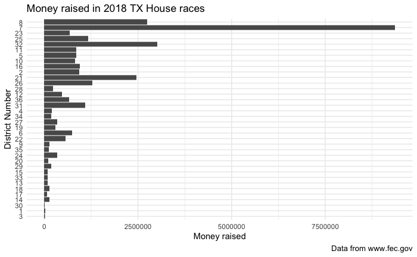

```r
TX_House %>%
  group_by(CAND_OFFICE_DISTRICT) %>%
  mutate(district_total=(sum(TOTAL))) %>%
  select(CAND_NAME, CAND_OFFICE_DISTRICT, CAND_PTY_AFFILIATION, TOTAL, district_total) %>%
  arrange(desc(district_total)) -> districts
ggplot(districts, aes(x=reorder(CAND_OFFICE_DISTRICT, district_total), district_total)) + geom_bar(stat="identity") + coord_flip() + theme_minimal() +
    labs(title="Money raised in 2018 TX House races",
       caption="Data from www.fec.gov",
       x="District Number",
       y="Money raised") -> districts_plot
districts_plot
```

I’m not sure why it is that this chart won’t reorder the way I want it to; suggestions welcome.

### Chart II

In the most expensive races, which parties’ candidates are raising more?

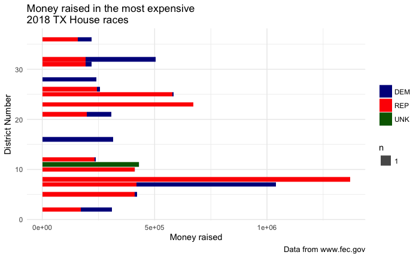

```r
ggplot(subset(districts, district_total>200000)) +
  geom_bar(aes(CAND_OFFICE_DISTRICT, TOTAL, fill=CAND_PTY_AFFILIATION), stat="sum") +
  coord_flip() + scale_fill_manual(values = c("DEM"="darkblue","REP"="red","UNK"="darkgreen")) +
  theme_minimal() +
  labs(title="Money raised in the most expensive \n2018 TX House races",
    caption="Data from www.fec.gov",
    x="District Number",
    y="Money raised") +
    guides(fill=guide_legend(title=NULL)) -> parties_plot
parties_plot
```

Things I’m not sure how to do on the chart above:

- Eliminate space between bars
- run `position_dodge()` by party
- Get rid of that “n 1” box
- Switch from e^ numbers to dollar amounts

### Two Charts Together

Putting these plots together:

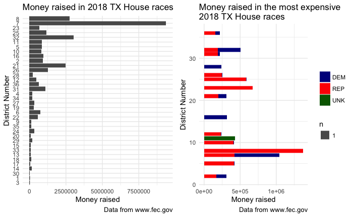

```r
grid.arrange(districts_plot, parties_plot, nrow=1)
```

In Part II, I’ll use the igraph packages to create a graph from this data. At the moment I’m currently stuck on `net <- graph_from_data_frame(d=links, vertices=nodes, directed=T)`.